# Analysis for SCORE replication of van Dijck et al. (2009)

```r
library(readr)
library(dplyr)
library(ggplot2)
library(tidyr)
library(purrr)
library(ez)
```

## Load in the data

Loading in lightly pre-processed data. The raw data from the experiment will be converted to match the form of the expected data. This will involve some minor filtering of irrelevant trials and columns. Raw data files will be preserved as will the scripts to convert the data to the form loaded here.

```r
all.parity.data <- read_csv('data/fake/testing_data.csv')
all.parity.data <- read_csv('data/pilot/parity-data.csv')
wm.data <- read_csv('data/pilot/wm-data.csv')
post.task.q.data <- read_csv('data/fake/self_include_data.csv')
post.task.q.data <- read_csv('data/pilot/self-include-data.csv')
```

## Subject inclusion criteria

Individual trials are excluded if:

- RT is greater than 4 SDs above the participant’s mean.
- RT is less than 250ms

```r
all.parity.data <- all.parity.data %>%
  group_by(subject) %>%
  mutate(include.trial = (rt <= mean(rt) + 4 * sd(rt)) & (rt >= 250)) %>%
  ungroup()

filtered.parity.data <- all.parity.data %>%
  filter(include.trial == TRUE)
```

To be included in the analysis the subject must:

- Have no more than 30% of trials excluded due to RT
- Recall at least 25% of the memory sequences correctly (at least 6 of 24)
- Median parity judgment RT must be smaller than 4SDs from the group’s median

```r
seventy.percent.inclusion <- all.parity.data %>%
  group_by(subject, phase) %>%
  summarize(p.include = sum(include.trial==TRUE) / n()) %>%
  group_by(subject) %>%
  summarize(seventy.percent.include = all(p.include >= 0.7)) # 640 total trials, 640 * 0.7 = 448

parity.acc.inclusion <- all.parity.data %>%
  group_by(phase, subject) %>%
  summarize(n.corr = sum(correct)) %>%
  mutate(include = if_else(phase=="dual", n.corr > 208, n.corr > 141)) %>%
  group_by(subject) %>%
  summarize(parity.include = all(include))

self.inclusion <- post.task.q.data %>%
  mutate(self.include = response == "Yes")

group.rt <- filtered.parity.data %>%
  group_by(subject) %>%
  filter(correct==TRUE) %>%
  summarize(median = median(rt)) %>%
  ungroup() %>%
  summarize(group.median = median(median), group.sd= sd(median))

rt.inclusion <- all.parity.data %>%
  group_by(subject) %>%
  filter(correct==TRUE) %>%
  summarize(median = median(rt)) %>%
  mutate(rt.include = median < (group.rt$group.median + 4*group.rt$group.sd))

mem.inclusion <- wm.data %>%
  group_by(subject) %>%
  summarize(n.correct = sum(correct)) %>%
  mutate(mem.include = n.correct >= 6)

final.include <- rt.inclusion %>%
  select(subject, rt.include) %>%
  left_join(seventy.percent.inclusion %>% select(subject, seventy.percent.include), by="subject") %>%
  left_join(self.inclusion %>% select(subject, self.include), by="subject") %>%
  left_join(mem.inclusion %>% select(subject, mem.include), by="subject") %>%
  left_join(parity.acc.inclusion %>% select(subject, parity.include), by="subject") %>%
  mutate(include = rt.include & mem.include & parity.include & self.include & seventy.percent.include)

good.subjects <- final.include %>%
  filter(include == TRUE) %>%
  pull(subject)
```

Apply inclusion criteria to data set, keeping only subjects who meet inclusion criteria.

```r
filtered.parity.data <- all.parity.data %>%
  filter(subject %in% good.subjects)

filtered.wm.data <- wm.data %>%
  filter(subject %in% good.subjects)
```

Find the total number of subjects left in each condition.

```r
filtered.parity.data %>%
  group_by(wmtask) %>%
  summarize(n.subjects = length(unique(subject)))
```

| wmtask | n.subjects |
| --- | --- |
| spatial | 1 |
| verbal | 1 |

## Working memory performance in phase 3

What percentage of memory items were correctly recalled in each condition?

```r
mem.phase.3 <- filtered.wm.data %>%
  group_by(subject, wmtask) %>%
  summarize(n.correct = sum(correct)) %>%
  mutate(percent.correct = (n.correct / 24)*100)

mem.phase.3.summary <- mem.phase.3 %>%
  group_by(wmtask) %>%
  summarize(mean.percent.correct = mean(percent.correct), sd = sd(percent.correct))

mem.phase.3.summary
```

| wmtask | mean.percent.correct | sd |
| --- | --- | --- |
| spatial | 29.16667 | NA |
| verbal | 45.83333 | NA |

Is there a statistically significant difference between recall for different WM types? (Original paper found that the verbal load was easier, with 95% correctly recalled vs. 76% in the spatial).

```r
t.test(n.correct ~ wmtask, data=mem.phase.3)
```

```
Error in t.test.default(x = 7, y = 11) : not enough 'x' observations
```

Is there evidence of a trade-off between WM performance and parity judgment performance in phase 3? (e.g., people who correctly recall more sequences are slower at correct parity judgments)

[figure not shown]

```r
cor.test(~ median.rt + percent.correct, data=(tradeoff.phase.3 %>% filter(wmtask=="spatial")))
```

```
Error in cor.test.default(x = 626.5, y = 29.1666666666667) :
  not enough finite observations
```

```r
cor.test(~ median.rt + percent.correct, data=(tradeoff.phase.3 %>% filter(wmtask=="verbal")))
```

```
Error in cor.test.default(x = 556.145, y = 45.8333333333333) :
  not enough finite observations
```

## Parity judgment analysis

### Calculating SNARC-effect measure

Calculate the `dRT` for each digit, in each phase, for each subject. `dRT` is the difference in median RT for correct responses when the correct response is on the right versus on the left.

```r
summary.drt <- filtered.parity.data %>%
  filter(correct==TRUE) %>%
  group_by(subject, phase, digit, targetkey, wmtask) %>%
  summarize(median.rt = median(rt)) %>%
  spread(targetkey, median.rt) %>%
  mutate(dRT = right - left)
```

Fit a linear model to each subject predicting `dRT` from digit magnitude.

```r
magnitude_model <- function(data){
  model.result <- lm(dRT ~ digit, data=data)
  return(as.numeric(model.result$coefficients[['digit']]))
}

lm.result <- summary.drt %>%
  group_by(subject, phase, wmtask) %>%
  nest() %>%
  mutate(dRT.coefficient = map(data, magnitude_model)) %>%
  select(-data) %>%
  unnest(cols=c(dRT.coefficient))
```

```r
covariate.diff <- filtered.parity.data %>%
  filter(correct==TRUE) %>%
  group_by(subject, phase) %>%
  summarize(median.rt = median(rt)) %>%
  spread(phase, median.rt) %>%
  mutate(phase.diff = dual - baseline) %>%
  select(subject, phase.diff)
```

```
Error: object 'dual' not found
```

### Focal test for SCORE H*

Fit ANCOVA model to data. Goal is to predict coefficients from the linear model. WM Task type (verbal v. spatial) is a between-subjects factor. Phase (baseline v. dual-task) is a within-subjects factor. Overall RT difference between phases is a between-subjects covariate.

The key test here is whether the interaction between WM task and phase is significant.

```r
anova.model <- ezANOVA(lm.result, dv = dRT.coefficient, between = wmtask, within = phase, between_covariates = phase.diff, wid = subject)

anova.model$ANOVA
```

|  | Effect | DFn | DFd | F | p | p<.05 | ges |
| --- | --- | --- | --- | --- | --- | --- | --- |
| 2 | wmtask | 1 | 0 | NaN | NaN | NA | 1 |
| 3 | phase | 1 | 0 | NaN | NaN | NA | 1 |
| 4 | wmtask:phase | 1 | 0 | NaN | NaN | NA | 1 |

Generate analogue of Fig. 1 from the target paper.

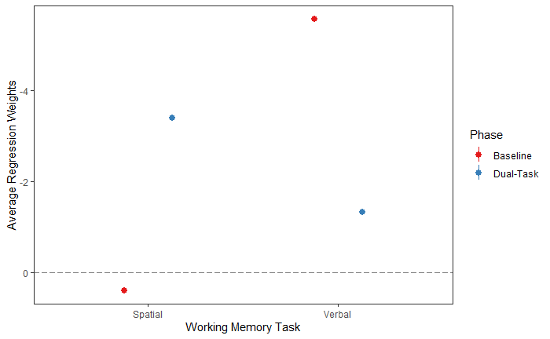

```r
plotting.data <- lm.result %>%
  group_by(wmtask, phase) %>%
  summarize(mean.coefficient = mean(dRT.coefficient), se = sd(dRT.coefficient) / sqrt(n()))

ggplot(plotting.data, aes(x=wmtask, y=mean.coefficient, ymin=mean.coefficient - se, ymax = mean.coefficient + se, color=phase))+
  geom_hline(yintercept = 0, color="grey50", linetype="longdash")+
  geom_pointrange(position = position_dodge2(width=0.5)) +
  scale_color_brewer(palette = "Set1", labels=c("Baseline", "Dual-Task"))+
  scale_x_discrete(labels=c("Spatial", "Verbal"))+
  labs(x="Working Memory Task", y="Average Regression Weights", color="Phase")+
  scale_y_reverse()+
  theme_bw() +
  theme(panel.grid = element_blank())
```

### Follow-up analyses

1. Is there a significant SNARC-effect in the baseline condition? Original paper found a significant effect.

```r
baseline.effect <- lm.result %>% filter(phase=="baseline")
t.test(baseline.effect$dRT.coefficient, alternative="less")
```

[output not shown]

2. Is there a significant SNARC-effect in the spatial-dual condition? Original paper found a significant effect.

```r
spatial.effect <- lm.result %>% filter(phase=="dual", wmtask=="spatial")
t.test(spatial.effect$dRT.coefficient, alternative="less")
```

[output not shown]

3. Is there no SNARC-effect in the verbal-dual condition? Original paper did not find a significant effect. Here we use an equivalence test to examine the evidence that the SNARC-effect in this condition is no larger than +/-1.5.

[figure not shown]

```r
library(TOSTER)
verbal.effect <- lm.result %>% filter(phase=="dual", wmtask=="verbal") %>%
  group_by(phase, wmtask) %>%
  summarize(m=mean(dRT.coefficient),sd=sd(dRT.coefficient),n=n())

TOSTER::TOSTone.raw(verbal.effect$m, mu=0, sd=verbal.effect$sd, n=verbal.effect$n,low_eqbound = -1.5,high_eqbound = 1.5, alpha=0.05, verbose=F)
```